# Lab 7: Heart Attack

Author

Lily

**GitHub Repository**: https://github.com/lilysteinberg/GSB-544---Computing-and-ML/tree/main/Week%207

# Part 0: Preparation

This hidden code loads in the necessary packages.

```python
# packages
import numpy as np
import pandas as pd
from sklearn.pipeline import Pipeline
from sklearn.compose import make_column_selector, ColumnTransformer
from sklearn.preprocessing import StandardScaler, OneHotEncoder
from sklearn.neighbors import KNeighborsClassifier
from sklearn.linear_model import LogisticRegression
from sklearn.tree import DecisionTreeClassifier
from sklearn.metrics import r2_score, mean_squared_error, classification_report, confusion_matrix, ConfusionMatrixDisplay, RocCurveDisplay, roc_auc_score, cohen_kappa_score
from sklearn.model_selection import GridSearchCV, train_test_split, cross_val_score, StratifiedKFold, cross_val_predict
from sklearn.inspection import permutation_importance
import matplotlib.pyplot as plt
```

This hidden code imports the data.

```python
# data
ha = pd.read_csv("https://www.dropbox.com/s/aohbr6yb9ifmc8w/heart_attack.csv?dl=1")
```

This hidden code previews and investigates the data to check if it needs cleaning. Output is commented out to reduce length of lab.

```python
# preview columns and data
#print(ha.head())

# statstical summary
#ha.describe()
# not worried about any outliers

# Missing data
#ha.isna().any()
# # no data missing

# Data Types
#ha.dtypes
# # all numeric columns are apporpriatly numeric already
```

# Part One: Fitting Models

```python
### specify x variables and y variable
X = ha.drop(columns = ["output"])
y = ha["output"]
```

```python
### set up column transformers
cat_cols = ['sex', 'cp', 'restecg']
num_cols = ['remainder__age', 'remainder__trtbps', 'remainder__chol', 'remainder__thalach']

ct_dummies = ColumnTransformer([('dummify', OneHotEncoder(sparse_output=False, handle_unknown='ignore'), cat_cols)],
                               remainder = 'passthrough').set_output(transform="pandas")

ct_standardize = ColumnTransformer([('standardize', StandardScaler(), num_cols)],
                               remainder = 'passthrough').set_output(transform="pandas")
```

**Q1: KNN**

```python
# make pipeline for knn tuning
knn_pipeline = Pipeline(
    [
     ("preprocessing1", ct_dummies),
     ("preprocessing2", ct_standardize),
     ("knn", KNeighborsClassifier())
    ],
).set_output(transform="pandas")

neighbors = {'knn__n_neighbors': np.arange(1, 11, 1)}

gscv = GridSearchCV(knn_pipeline, param_grid=neighbors, cv = 5, scoring='roc_auc')

# feed in data
gscv_fitted = gscv.fit(X, y)
gscv_fitted.cv_results_

# view results
df_cv_results_ = pd.DataFrame(gscv_fitted.cv_results_)
df_cv_results_
```

|  | mean_fit_time | std_fit_time | mean_score_time | std_score_time | param_knn__n_neighbors | params | split0_test_score | split1_test_score | split2_test_score | split3_test_score | split4_test_score | mean_test_score | std_test_score | rank_test_score |
| --- | --- | --- | --- | --- | --- | --- | --- | --- | --- | --- | --- | --- | --- | --- |
| 0 | 0.013699 | 0.004536 | 0.011363 | 0.001213 | 1 | {'knn__n_neighbors': 1} | 0.743333 | 0.692971 | 0.656499 | 0.759310 | 0.659310 | 0.702285 | 0.042348 | 10 |
| 1 | 0.011725 | 0.002691 | 0.009003 | 0.000648 | 2 | {'knn__n_neighbors': 2} | 0.743333 | 0.786472 | 0.688992 | 0.813793 | 0.681379 | 0.742794 | 0.052183 | 9 |
| 2 | 0.009057 | 0.000827 | 0.008301 | 0.000477 | 3 | {'knn__n_neighbors': 3} | 0.742667 | 0.842175 | 0.747347 | 0.877241 | 0.656552 | 0.773196 | 0.078472 | 7 |
| 3 | 0.012831 | 0.001937 | 0.011442 | 0.001864 | 4 | {'knn__n_neighbors': 4} | 0.742000 | 0.825597 | 0.778515 | 0.887586 | 0.646897 | 0.776119 | 0.080921 | 6 |
| 4 | 0.016292 | 0.005323 | 0.013240 | 0.002960 | 5 | {'knn__n_neighbors': 5} | 0.750667 | 0.793767 | 0.803714 | 0.872414 | 0.641379 | 0.772388 | 0.076261 | 8 |
| 5 | 0.014366 | 0.004452 | 0.013046 | 0.003663 | 6 | {'knn__n_neighbors': 6} | 0.730667 | 0.801724 | 0.820292 | 0.882069 | 0.650345 | 0.777019 | 0.079641 | 5 |
| 6 | 0.012367 | 0.003976 | 0.011165 | 0.003503 | 7 | {'knn__n_neighbors': 7} | 0.760000 | 0.817639 | 0.823607 | 0.886897 | 0.650345 | 0.787698 | 0.079573 | 4 |
| 7 | 0.011113 | 0.001767 | 0.011331 | 0.002928 | 8 | {'knn__n_neighbors': 8} | 0.768000 | 0.832228 | 0.811671 | 0.884138 | 0.662069 | 0.791621 | 0.074769 | 3 |
| 8 | 0.011554 | 0.002061 | 0.009749 | 0.001205 | 9 | {'knn__n_neighbors': 9} | 0.786667 | 0.853448 | 0.809682 | 0.874483 | 0.675862 | 0.800028 | 0.069406 | 2 |
| 9 | 0.010139 | 0.002330 | 0.009497 | 0.001438 | 10 | {'knn__n_neighbors': 10} | 0.805333 | 0.856101 | 0.814324 | 0.875172 | 0.682759 | 0.806738 | 0.067157 | 1 |

neighbors = 10 performs the best.

```python
# make pipeline for neighbors = 10
knn_best_pipeline = Pipeline(
  [
   ("preprocessing1", ct_dummies),
   ("preprocessing2", ct_standardize),
   ("knn", KNeighborsClassifier(n_neighbors = 10))
  ]
).set_output(transform="pandas")

# fit
knn_best_pipeline_fitted = knn_best_pipeline.fit(X, y)

# cross-validation to estimate ROC AUC
scores = cross_val_score(knn_best_pipeline,
                         X=X,
                         y=y,
                         scoring="roc_auc",
                         cv=5)
scores.mean()
```

```
np.float64(0.8067377541998232)
```

The cross-validated ROC AUC = 0.8067377541998232.

```python
# classification report for accuracy, precision, recall, f1
y_pred_knn = cross_val_predict(knn_best_pipeline, X, y, cv=5)
print(classification_report(y, y_pred_knn))
```

```
              precision    recall  f1-score   support

           0       0.68      0.81      0.74       127
           1       0.80      0.67      0.73       146

    accuracy                           0.74       273
   macro avg       0.74      0.74      0.74       273
weighted avg       0.75      0.74      0.74       273
```

```
[[103  24]
 [ 48  98]]
```

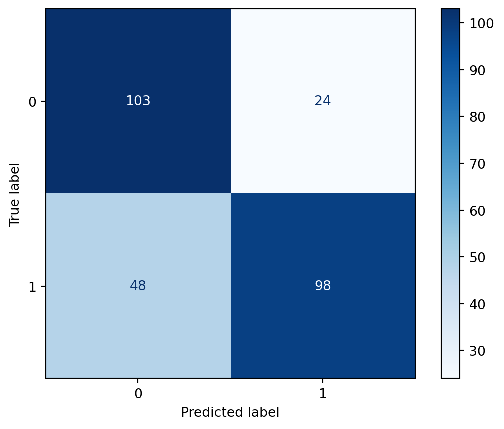

```python
# confusion matrix
print(confusion_matrix(y, y_pred_knn))

# visualize confusion matrix
ConfusionMatrixDisplay.from_predictions(
                                      y,
                                      y_pred_knn,
                                      cmap = plt.cm.Blues)
```

```python
### feature importance
X_transformed = knn_best_pipeline[:-1].transform(X)

feature_importance = pd.DataFrame()
feature_importance['variable_name'] = knn_best_pipeline[:-1].get_feature_names_out()
feature_importance['feature_importance'] = permutation_importance(knn_best_pipeline.named_steps["knn"], X_transformed, y, n_repeats=10, random_state=42).importances_mean

# display
feature_importance.sort_values(by = "feature_importance", ascending = False)
```

|  | variable_name | feature_importance |
| --- | --- | --- |
| 3 | standardize__remainder__thalach | 0.063370 |
| 4 | remainder__dummify__sex_0 | 0.017216 |
| 5 | remainder__dummify__sex_1 | 0.017216 |
| 6 | remainder__dummify__cp_0 | 0.016850 |
| 7 | remainder__dummify__cp_1 | 0.011722 |
| 0 | standardize__remainder__age | 0.005861 |
| 9 | remainder__dummify__cp_3 | 0.000733 |
| 12 | remainder__dummify__restecg_2 | 0.000000 |
| 8 | remainder__dummify__cp_2 | -0.005861 |
| 10 | remainder__dummify__restecg_0 | -0.010623 |
| 1 | standardize__remainder__trtbps | -0.012821 |
| 11 | remainder__dummify__restecg_1 | -0.014652 |
| 2 | standardize__remainder__chol | -0.024176 |

**Q2: Logistic Regression**

```python
# making adjustments to X variables to optimize model
X_logistic = ha.drop(columns = ["output"])
X_logistic['age'] = np.log(X_logistic['age'])
X_logistic["age:sex"] = X_logistic["age"] * X_logistic["sex"]

# rejected transformations I tested
#X_logistic['chol'] = np.log(X_logistic['chol'])
#X_logistic["trtbps:chol"] = X_logistic["trtbps"] * X_logistic["chol"]
#X_logistic["thalach:cp"] = X_logistic["thalach"] * X_logistic["cp"]
#X_logistic["sex:cp"] = X_logistic["sex"] * X_logistic["cp"]
#X_logistic["age:thalach"] = X_logistic["age"] * X_logistic["thalach"]

# create new column transformer to drop first dummy variable to avoid the dummy variable trap
ct_dummies_logistic = ColumnTransformer([('dummify', OneHotEncoder(sparse_output=False, handle_unknown='ignore', drop='first'), cat_cols)],
                               remainder = 'passthrough').set_output(transform="pandas")
```

```python
# make pipeline for logistic tuning
logistic_pipeline = Pipeline(
  [
   ("preprocessing1", ct_dummies_logistic),
   ("preprocessing2", ct_standardize),
   ("logistic", LogisticRegression(penalty = 'l1'))
  ]
).set_output(transform="pandas")

# tune lasso penalty hyperparameter
param_grid = [
    {'logistic__penalty': ['l1', 'none'],
     'logistic__C': np.array([0.001, 0.01, 0.1, 1, 10, 100]),
     'logistic__solver': ['liblinear', 'saga']
    }
]

gscv = GridSearchCV(logistic_pipeline, param_grid=param_grid, cv = 5, scoring='roc_auc')

# feed in the data
gscv_fitted = gscv.fit(X_logistic, y)

# view results
df_cv_results_ = pd.DataFrame(gscv_fitted.cv_results_)
df_cv_results_
```

[output not shown]

[output cut: 39 more lines]

[output not shown]

|  | mean_fit_time | std_fit_time | mean_score_time | std_score_time | param_logistic__C | param_logistic__penalty | param_logistic__solver | params | split0_test_score | split1_test_score | split2_test_score | split3_test_score | split4_test_score | mean_test_score | std_test_score | rank_test_score |
| --- | --- | --- | --- | --- | --- | --- | --- | --- | --- | --- | --- | --- | --- | --- | --- | --- |
| 0 | 0.010992 | 0.001120 | 0.007867 | 0.000618 | 0.001 | l1 | liblinear | {'logistic__C': 0.001, 'logistic__penalty': 'l... | 0.500000 | 0.500000 | 0.500000 | 0.500000 | 0.500000 | 0.500000 | 0.000000 | 9 |
| 1 | 0.010032 | 0.000202 | 0.007565 | 0.000695 | 0.001 | l1 | saga | {'logistic__C': 0.001, 'logistic__penalty': 'l... | 0.500000 | 0.500000 | 0.500000 | 0.500000 | 0.500000 | 0.500000 | 0.000000 | 9 |
| 2 | 0.008531 | 0.000541 | 0.000000 | 0.000000 | 0.001 | none | liblinear | {'logistic__C': 0.001, 'logistic__penalty': 'n... | NaN | NaN | NaN | NaN | NaN | NaN | NaN | 13 |
| 3 | 0.008358 | 0.000290 | 0.000000 | 0.000000 | 0.001 | none | saga | {'logistic__C': 0.001, 'logistic__penalty': 'n... | NaN | NaN | NaN | NaN | NaN | NaN | NaN | 13 |
| 4 | 0.009815 | 0.000307 | 0.007074 | 0.000321 | 0.010 | l1 | liblinear | {'logistic__C': 0.01, 'logistic__penalty': 'l1... | 0.500000 | 0.500000 | 0.500000 | 0.500000 | 0.500000 | 0.500000 | 0.000000 | 9 |
| 5 | 0.009438 | 0.000510 | 0.007977 | 0.000391 | 0.010 | l1 | saga | {'logistic__C': 0.01, 'logistic__penalty': 'l1... | 0.500000 | 0.500000 | 0.500000 | 0.500000 | 0.500000 | 0.500000 | 0.000000 | 9 |
| 6 | 0.008910 | 0.000787 | 0.000000 | 0.000000 | 0.010 | none | liblinear | {'logistic__C': 0.01, 'logistic__penalty': 'no... | NaN | NaN | NaN | NaN | NaN | NaN | NaN | 13 |
| 7 | 0.008367 | 0.000407 | 0.000000 | 0.000000 | 0.010 | none | saga | {'logistic__C': 0.01, 'logistic__penalty': 'no... | NaN | NaN | NaN | NaN | NaN | NaN | NaN | 13 |
| 8 | 0.009975 | 0.000673 | 0.008026 | 0.000305 | 0.100 | l1 | liblinear | {'logistic__C': 0.1, 'logistic__penalty': 'l1'... | 0.750667 | 0.874005 | 0.859416 | 0.840000 | 0.680000 | 0.800818 | 0.074078 | 8 |
| 9 | 0.010450 | 0.000270 | 0.007597 | 0.000790 | 0.100 | l1 | saga | {'logistic__C': 0.1, 'logistic__penalty': 'l1'... | 0.772000 | 0.839523 | 0.848806 | 0.871724 | 0.702069 | 0.806824 | 0.062016 | 7 |
| 10 | 0.009924 | 0.000596 | 0.000000 | 0.000000 | 0.100 | none | liblinear | {'logistic__C': 0.1, 'logistic__penalty': 'non... | NaN | NaN | NaN | NaN | NaN | NaN | NaN | 13 |
| 11 | 0.010885 | 0.001099 | 0.000000 | 0.000000 | 0.100 | none | saga | {'logistic__C': 0.1, 'logistic__penalty': 'non... | NaN | NaN | NaN | NaN | NaN | NaN | NaN | 13 |
| 12 | 0.014682 | 0.003127 | 0.009908 | 0.002322 | 1.000 | l1 | liblinear | {'logistic__C': 1.0, 'logistic__penalty': 'l1'... | 0.825333 | 0.889920 | 0.907162 | 0.914483 | 0.788966 | 0.865173 | 0.049400 | 2 |
| 13 | 0.017083 | 0.003704 | 0.010350 | 0.001653 | 1.000 | l1 | saga | {'logistic__C': 1.0, 'logistic__penalty': 'l1'... | 0.824000 | 0.892573 | 0.909814 | 0.918621 | 0.793103 | 0.867622 | 0.049919 | 1 |
| 14 | 0.014465 | 0.001246 | 0.000000 | 0.000000 | 1.000 | none | liblinear | {'logistic__C': 1.0, 'logistic__penalty': 'non... | NaN | NaN | NaN | NaN | NaN | NaN | NaN | 13 |
| 15 | 0.015387 | 0.003271 | 0.000000 | 0.000000 | 1.000 | none | saga | {'logistic__C': 1.0, 'logistic__penalty': 'non... | NaN | NaN | NaN | NaN | NaN | NaN | NaN | 13 |
| 16 | 0.012246 | 0.001400 | 0.008483 | 0.002052 | 10.000 | l1 | liblinear | {'logistic__C': 10.0, 'logistic__penalty': 'l1... | 0.829333 | 0.880637 | 0.908488 | 0.914483 | 0.790345 | 0.864657 | 0.047810 | 3 |
| 17 | 0.012731 | 0.000472 | 0.007497 | 0.000291 | 10.000 | l1 | saga | {'logistic__C': 10.0, 'logistic__penalty': 'l1... | 0.828000 | 0.880637 | 0.908488 | 0.914483 | 0.790345 | 0.864390 | 0.048010 | 4 |
| 18 | 0.008842 | 0.000372 | 0.000000 | 0.000000 | 10.000 | none | liblinear | {'logistic__C': 10.0, 'logistic__penalty': 'no... | NaN | NaN | NaN | NaN | NaN | NaN | NaN | 13 |
| 19 | 0.008498 | 0.000500 | 0.000000 | 0.000000 | 10.000 | none | saga | {'logistic__C': 10.0, 'logistic__penalty': 'no... | NaN | NaN | NaN | NaN | NaN | NaN | NaN | 13 |
| 20 | 0.019686 | 0.009402 | 0.009499 | 0.002095 | 100.000 | l1 | liblinear | {'logistic__C': 100.0, 'logistic__penalty': 'l... | 0.829333 | 0.876658 | 0.907162 | 0.914483 | 0.782069 | 0.861941 | 0.049930 | 6 |
| 21 | 0.016305 | 0.002958 | 0.010819 | 0.003425 | 100.000 | l1 | saga | {'logistic__C': 100.0, 'logistic__penalty': 'l... | 0.826667 | 0.879310 | 0.907162 | 0.914483 | 0.786207 | 0.862766 | 0.049161 | 5 |
| 22 | 0.009579 | 0.001493 | 0.000000 | 0.000000 | 100.000 | none | liblinear | {'logistic__C': 100.0, 'logistic__penalty': 'n... | NaN | NaN | NaN | NaN | NaN | NaN | NaN | 13 |
| 23 | 0.011069 | 0.003003 | 0.000000 | 0.000000 | 100.000 | none | saga | {'logistic__C': 100.0, 'logistic__penalty': 'n... | NaN | NaN | NaN | NaN | NaN | NaN | NaN | 13 |

penalty = l1 (lasso), C = 1, and solver = “saga” performs the best.

```python
# make pipeline for C = 1, penalty = l1 (lasso), and solver = "saga"
logistic_best_pipeline = Pipeline(
  [
   ("preprocessing1", ct_dummies_logistic),
   ("preprocessing2", ct_standardize),
   ("logistic", LogisticRegression(penalty = 'l1', C = 1.0, solver = 'saga'))
  ]
).set_output(transform="pandas")

# fit
logistic_best_pipeline_fitted = logistic_best_pipeline.fit(X_logistic, y)

# cross-validation to estimate ROC AUC
scores = cross_val_score(logistic_best_pipeline,
                         X=X_logistic,
                         y=y,
                         scoring="roc_auc",
                         cv=5)
scores.mean()
```

```
np.float64(0.8676222811671088)
```

The cross-validated ROC AUC = 0.8676222811671088.

This was the highest ROC AUC managed. I transformed the age variable into log(age) and created an interaction term between age and sex. I tested other transformations. See the commented out code above for details.

```python
# classification report for accuracy, precision, recall, f1
y_pred_lg = cross_val_predict(logistic_best_pipeline, X_logistic, y, cv=5)
print(classification_report(y, y_pred_lg))
```

```
              precision    recall  f1-score   support

           0       0.78      0.74      0.76       127
           1       0.78      0.82      0.80       146

    accuracy                           0.78       273
   macro avg       0.78      0.78      0.78       273
weighted avg       0.78      0.78      0.78       273
```

```
[[ 94  33]
 [ 27 119]]
```

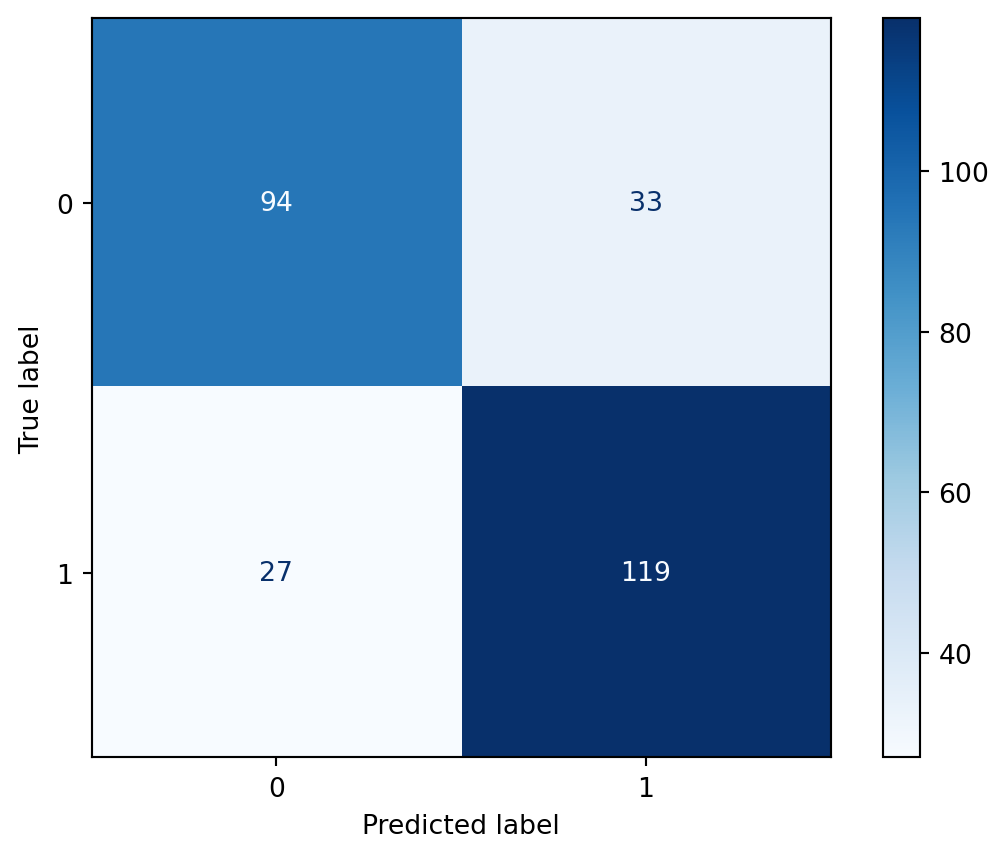

```python
# confusion matrix
print(confusion_matrix(y, y_pred_lg))

# visualize confusion matrix
ConfusionMatrixDisplay.from_predictions(
                                      y,
                                      y_pred_lg,
                                      cmap = plt.cm.Blues)
```

```python
# create dataframe for storing coefficients
coef_compare = pd.DataFrame()
coef_compare['variable_name'] = pd.DataFrame(logistic_best_pipeline.named_steps["preprocessing1"].get_feature_names_out())
coef_compare['logistic coefficients'] = logistic_best_pipeline_fitted.named_steps['logistic'].coef_.flatten()
coef_compare["abs_coefs"] = coef_compare["logistic coefficients"].abs()

# display
coef_compare.sort_values(by = "abs_coefs", ascending = False)
```

|  | variable_name | logistic coefficients | abs_coefs |
| --- | --- | --- | --- |
| 5 | dummify__restecg_2 | 1.872499 | 1.872499 |
| 6 | remainder__age | 1.760938 | 1.760938 |
| 7 | remainder__trtbps | 1.427493 | 1.427493 |
| 3 | dummify__cp_3 | 0.776963 | 0.776963 |
| 10 | remainder__age:sex | -0.500063 | 0.500063 |
| 1 | dummify__cp_1 | -0.300573 | 0.300573 |
| 2 | dummify__cp_2 | -0.272559 | 0.272559 |
| 8 | remainder__chol | 0.270336 | 0.270336 |
| 0 | dummify__sex_1 | -0.163410 | 0.163410 |
| 4 | dummify__restecg_1 | 0.000000 | 0.000000 |
| 9 | remainder__thalach | 0.000000 | 0.000000 |

This hidden code contains the math used to interpret the coefficients.

```python
# math for coefficient interpretations:
# percent change in odds = (exp (bj ) – 1) x 100

### restecg
#(np.exp(0)-1)*100 #returns 0
#(np.exp(1.872484)-1)*100 #returns 550.4433361351994

### age
## log(age)'s coefficient // log(age)'s effect when sex = 0
#2**1.760940 # returns 3.3891887844543898
## age:sex's coefficient
#2**-0.472809 # returns 0.7070734531951167
## log(age)'s effect when sex = 1
#3.3891887844543898 + 0.7070734531951167 # returns 4.096262237649507

### trtbps
#(np.exp(1.427516)-1)*100 #returns 316.8332184284586

## cp
#(np.exp(-0.300585)-1)*100 #returns -25.961503123883833
#(np.exp(-0.272560)-1)*100 #returns -23.857225785992053
#(np.exp(0.776952)-1)*100 #returns 117.48332610156571

### sex (with interaction)
#(np.exp(-0.163408)-1)*100 + (np.exp(-0.500068)*100) #returns 45.573404294331496

### chol
#(np.exp(0.270352)-1)*100 # returns 31.042563938434608

### thalach
#(np.exp(0)-1)*100 # returns 0
```

Coefficient interpretation:

*Note: lasso tuning turned the coefficients for restecg_1 and thalach to 0.*

**Q3: Decision Tree**

```python
# make pipeline for decision tree tuning
dt_pipeline = Pipeline(
    [
     ("preprocessing1", ct_dummies),
     ("dt", DecisionTreeClassifier())
    ],
).set_output(transform="pandas")

tuning = {
    'dt__ccp_alpha': np.arange(0, 1, 0.1),
    'dt__max_depth': np.arange(1,10, 1),
    #'dt__min_samples_split': np.arange(1, 273, 1)
}

gscv = GridSearchCV(dt_pipeline, param_grid=tuning, cv = 5, scoring='roc_auc')

# feed in data
gscv_fitted = gscv.fit(X, y)
gscv_fitted.cv_results_

# view results
df_cv_results_ = pd.DataFrame(gscv_fitted.cv_results_)
df_cv_results_
```

|  | mean_fit_time | std_fit_time | mean_score_time | std_score_time | param_dt__ccp_alpha | param_dt__max_depth | params | split0_test_score | split1_test_score | split2_test_score | split3_test_score | split4_test_score | mean_test_score | std_test_score | rank_test_score |
| --- | --- | --- | --- | --- | --- | --- | --- | --- | --- | --- | --- | --- | --- | --- | --- |
| 0 | 0.010425 | 0.002743 | 0.009107 | 0.002405 | 0.0 | 1 | {'dt__ccp_alpha': 0.0, 'dt__max_depth': 1} | 0.796667 | 0.746684 | 0.727454 | 0.776552 | 0.719310 | 0.753333 | 0.029286 | 4 |
| 1 | 0.009036 | 0.002694 | 0.007327 | 0.001738 | 0.0 | 2 | {'dt__ccp_alpha': 0.0, 'dt__max_depth': 2} | 0.809333 | 0.814324 | 0.773210 | 0.727586 | 0.735862 | 0.772063 | 0.035958 | 2 |
| 2 | 0.006985 | 0.000819 | 0.006057 | 0.000767 | 0.0 | 3 | {'dt__ccp_alpha': 0.0, 'dt__max_depth': 3} | 0.826000 | 0.824271 | 0.791777 | 0.756552 | 0.689655 | 0.777651 | 0.050792 | 1 |
| 3 | 0.008254 | 0.001778 | 0.007656 | 0.001888 | 0.0 | 4 | {'dt__ccp_alpha': 0.0, 'dt__max_depth': 4} | 0.742000 | 0.811671 | 0.777851 | 0.767586 | 0.700690 | 0.759960 | 0.037116 | 3 |
| 4 | 0.008074 | 0.001557 | 0.007060 | 0.001338 | 0.0 | 5 | {'dt__ccp_alpha': 0.0, 'dt__max_depth': 5} | 0.647333 | 0.709549 | 0.791114 | 0.728966 | 0.666897 | 0.708772 | 0.050432 | 15 |
| ... | ... | ... | ... | ... | ... | ... | ... | ... | ... | ... | ... | ... | ... | ... | ... |
| 85 | 0.009344 | 0.002908 | 0.008311 | 0.001912 | 0.9 | 5 | {'dt__ccp_alpha': 0.9, 'dt__max_depth': 5} | 0.500000 | 0.500000 | 0.500000 | 0.500000 | 0.500000 | 0.500000 | 0.000000 | 19 |
| 86 | 0.009235 | 0.002213 | 0.007802 | 0.002075 | 0.9 | 6 | {'dt__ccp_alpha': 0.9, 'dt__max_depth': 6} | 0.500000 | 0.500000 | 0.500000 | 0.500000 | 0.500000 | 0.500000 | 0.000000 | 19 |
| 87 | 0.008560 | 0.002167 | 0.006045 | 0.001961 | 0.9 | 7 | {'dt__ccp_alpha': 0.9, 'dt__max_depth': 7} | 0.500000 | 0.500000 | 0.500000 | 0.500000 | 0.500000 | 0.500000 | 0.000000 | 19 |
| 88 | 0.006828 | 0.001527 | 0.005443 | 0.000837 | 0.9 | 8 | {'dt__ccp_alpha': 0.9, 'dt__max_depth': 8} | 0.500000 | 0.500000 | 0.500000 | 0.500000 | 0.500000 | 0.500000 | 0.000000 | 19 |
| 89 | 0.005927 | 0.000175 | 0.004597 | 0.000205 | 0.9 | 9 | {'dt__ccp_alpha': 0.9, 'dt__max_depth': 9} | 0.500000 | 0.500000 | 0.500000 | 0.500000 | 0.500000 | 0.500000 | 0.000000 | 19 |

90 rows × 15 columns

ccp_alpha = 0.0 with max_depth = 3 performs the best.

```python
# make pipeline for ccp_alpha = 0.0 and max_depth = 3
dt_best_pipeline = Pipeline(
    [
     ("preprocessing1", ct_dummies),
     ("dt", DecisionTreeClassifier(ccp_alpha=0.0, max_depth=3))
    ],
).set_output(transform="pandas")

# fit
dt_best_pipeline_fitted = dt_best_pipeline.fit(X, y)

# cross-validation to estimate ROC AUC
scores = cross_val_score(dt_best_pipeline,
                         X=X,
                         y=y,
                         scoring="roc_auc",
                         cv=5)
scores.mean()
```

```
np.float64(0.7710196286472148)
```

The cross-validated ROC AUC = 0.7710196286472148.

```python
# classification report for accuracy, precision, recall, f1
y_pred_dt = cross_val_predict(dt_best_pipeline, X, y, cv=5)
print(classification_report(y, y_pred_dt))
```

```
              precision    recall  f1-score   support

           0       0.72      0.78      0.75       127
           1       0.79      0.74      0.77       146

    accuracy                           0.76       273
   macro avg       0.76      0.76      0.76       273
weighted avg       0.76      0.76      0.76       273
```

```
[[ 99  28]
 [ 38 108]]
```

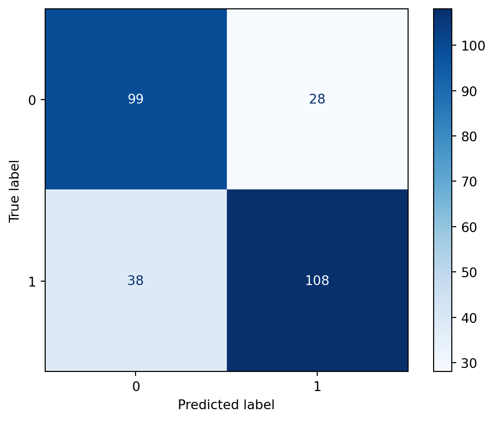

```python
# confusion matrix
print(confusion_matrix(y, y_pred_dt))

# visualize confusion matrix
ConfusionMatrixDisplay.from_predictions(
                                      y,
                                      y_pred_dt,
                                      cmap = plt.cm.Blues)
```

```python
### feature importance
feature_importance = pd.DataFrame()
feature_importance['variable_name'] = dt_best_pipeline.named_steps["preprocessing1"].get_feature_names_out()
feature_importance['feature_importance'] = dt_best_pipeline.named_steps["dt"].feature_importances_

# display
feature_importance.sort_values(by = "feature_importance", ascending = False)
```

|  | variable_name | feature_importance |
| --- | --- | --- |
| 2 | dummify__cp_0 | 0.564630 |
| 9 | remainder__age | 0.151122 |
| 12 | remainder__thalach | 0.112866 |
| 1 | dummify__sex_1 | 0.099147 |
| 10 | remainder__trtbps | 0.072235 |
| 4 | dummify__cp_2 | 0.000000 |
| 3 | dummify__cp_1 | 0.000000 |
| 0 | dummify__sex_0 | 0.000000 |
| 5 | dummify__cp_3 | 0.000000 |
| 8 | dummify__restecg_2 | 0.000000 |
| 7 | dummify__restecg_1 | 0.000000 |
| 6 | dummify__restecg_0 | 0.000000 |
| 11 | remainder__chol | 0.000000 |

**Q4. Interpretation**

Which predictors were most important to predicting heart attack risk?

- In the KNN model, the most important predictors were maximum heart rate during exercise (thalch), sex, and an absence of chest pain (cp, value 0). For the full, ranked list, see Part 1, Q1.
- In the logistic regression model, the most important predictors were resting electrocardiographic results when showing probable or definite left ventricular hypertrophy (restecg, value 2), age, and resting blood pressure (trtbps). For the full, ranked list, see Part 1, Q2.
- In the decision tree model, the most important predictors were an absence of chest pain (cp, value 0), age, and maximum heart rate during exercise (thalch). For the full, ranked list, see Part 1, Q3.

**Q5. ROC Curve**

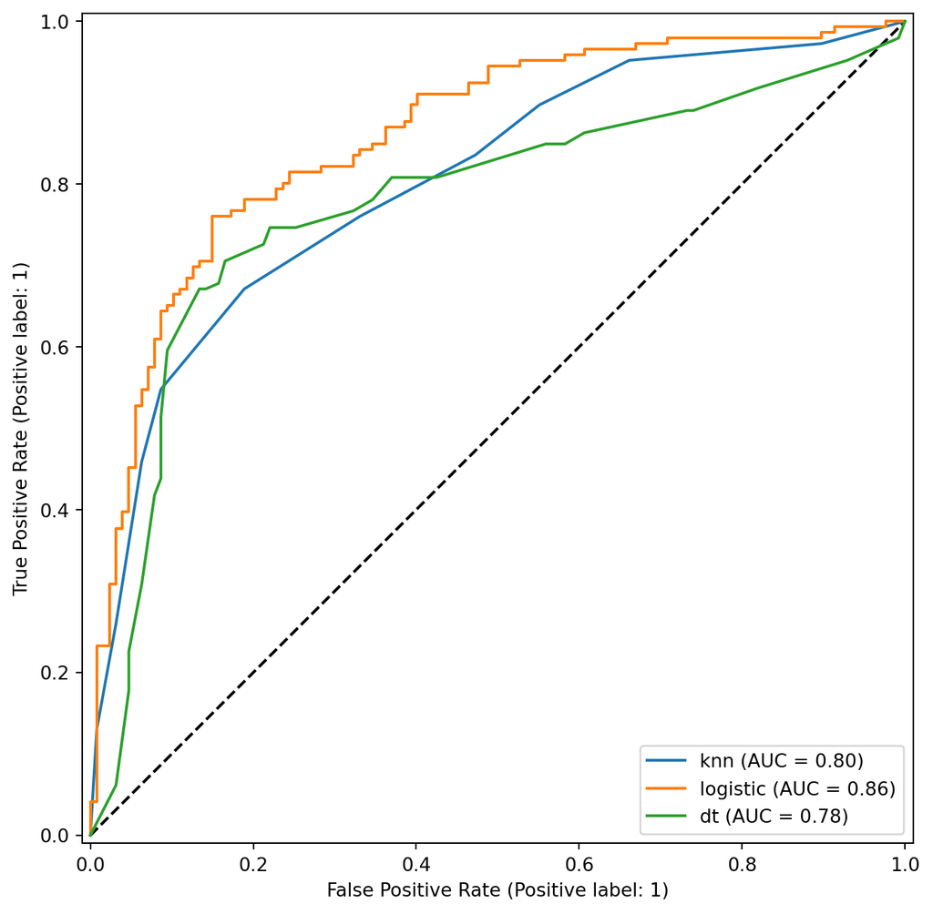

```python
# get predicted probabilities
y_knn_proba = cross_val_predict(knn_best_pipeline, X, y, cv=5, method='predict_proba')[:, 1]
y_log_proba = cross_val_predict(logistic_best_pipeline, X_logistic, y, cv=5, method='predict_proba')[:, 1]
y_dt_proba = cross_val_predict(dt_best_pipeline, X, y, cv=5, method='predict_proba')[:, 1]

# plot ROC curves from predictions
fig, ax = plt.subplots(figsize = (8, 8))
ax.plot(ax.get_xlim(), ax.get_ylim(), ls = '--', c = 'k')

RocCurveDisplay.from_predictions(y, y_knn_proba, ax=ax, name="knn")
RocCurveDisplay.from_predictions(y, y_log_proba, ax=ax, name="logistic")
RocCurveDisplay.from_predictions(y, y_dt_proba, ax=ax, name="dt")
```

# Part Two: Metrics

These values were included in the classification reports produced in Part 1. Sensitivity is recall for the target class, precision is for the target class, and specificity is recall for the non-target class. The results are summarized below:

**KNN**

- Sensitivity: 0.67
- Precision: 0.80
- Specificity: 0.81

**Logistic Regression**

- Sensitivity: 0.82
- Precision: 0.78
- Specificity: 0.74

**Decision Tree**

- Sensitivity: 0.74
- Precision: 0.79
- Specificity: 0.78

# Part Three: Discussion

**Q1. The hospital faces severe lawsuits if they deem a patient to be low risk, and that patient later experiences a heart attack.**

Which metric(s) you would use for model selection and why.

- I’d use sensitivity = true positive / (true positive + false negative), since it accounts for the proportion of positive cases out of all truly positive cases and takes into account false negatives. This situation describes the repercussions of false negatives, so I would want a metric that accounts for it.

Which of your final models (Part One Q1-3) you would recommend to the hospital, and why.

- I’d recommend the logistic regression model because it has the highest sensitivity, which suggests the lowest false negative rate.

What score you should expect for your chosen metric(s) using your chosen model to predict future observations.

- I’d expect the sensitivity score to be about 0.82.

**Q2. The hospital is overfull, and wants to only use bed space for patients most in need of monitoring due to heart attack risk.**

Which metric(s) you would use for model selection and why.

- I’d use precision = true positive / (true positive + false positive), since it accounts for the amount of positive predictions made by the model that are truly positive. This situation describes the importance of identifying true positives, so I would want a metric that accounts for it.

Which of your final models (Part One Q1-3) you would recommend to the hospital, and why.

What score you should expect for your chosen metric(s) using your chosen model to predict future observations.

- I’d expect the precision score to be about 0.80.

**Q3. The hospital is studying root causes of heart attacks, and would like to understand which biological measures are associated with heart attack risk.**

Which metric(s) you would use for model selection and why.

Which of your final models (Part One Q1-3) you would recommend to the hospital, and why.

- I’d recommend the logistic regression model because it has the highest sensitivity. Additionally, with the lasso penalty, the regression shows which variables are most impactful to consider and sets the rest to 0, which can help show which biological measures are associated with heart attack risk.

What score you should expect for your chosen metric(s) using your chosen model to predict future observations.

- I’d expect the sensitivity score to be about 0.82.

**Q4. The hospital is training a new batch of doctors, and they would like to compare the diagnoses of these doctors to the predictions given by the algorithm to measure the ability of new doctors to diagnose patients.**

Which metric(s) you would use for model selection and why.

- I’d use accuracy = (true positive + true negative) / (true positive + true negative + false positive + false negative), since it accounts for the proportion of accurate diagnoses (true positive and true negative) out of all possible situations. The posed situation can have new doctors diagnosing correctly and incorrectly, for both heart attack and non-heart attack cases, so accuracy would account for all potential instances.

Which of your final models (Part One Q1-3) you would recommend to the hospital, and why.

- I’d recommend the logistic regression model because it has the highest accuracy (0.78) compared to the KNN (0.74) and decision tree (0.76) models.

What score you should expect for your chosen metric(s) using your chosen model to predict future observations.

- I’d expect the accuracy score to be about 0.78.

# Part Four: Validation

```python
# import new data
ha_validation = pd.read_csv("https://www.dropbox.com/s/jkwqdiyx6o6oad0/heart_attack_validation.csv?dl=1")

# assign X and y variables
X_test = ha_validation.drop(columns = ["output"])
y_test = ha_validation["output"]

# logistic regression's transformations
X_logistic_test = ha_validation.drop(columns = ["output"])
X_logistic_test['age'] = np.log(X_logistic_test['age'])
X_logistic_test["age:sex"] = X_logistic_test["age"] * X_logistic_test["sex"]
```

**KNN**

```python
# cross-validation to estimate ROC AUC
scores = cross_val_score(knn_best_pipeline,
                         X=X_test,
                         y=y_test,
                         scoring="roc_auc",
                         cv=5)
scores.mean()
```

```
np.float64(0.7513888888888889)
```

The cross-validated ROC AUC = 0.7513888888888889.

```python
# classification report for accuracy, precision, recall, f1
y_pred = cross_val_predict(knn_best_pipeline, X_test, y_test, cv=5)
print(classification_report(y_test, y_pred))
```

```
              precision    recall  f1-score   support

           0       1.00      0.36      0.53        11
           1       0.73      1.00      0.84        19

    accuracy                           0.77        30
   macro avg       0.87      0.68      0.69        30
weighted avg       0.83      0.77      0.73        30
```

```
[[ 4  7]
 [ 0 19]]
```

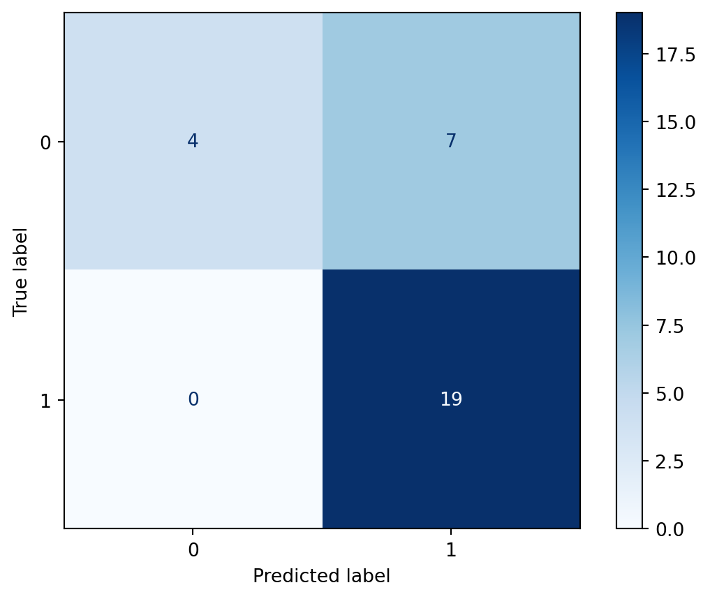

```python
# confusion matrix
print(confusion_matrix(y_test, y_pred))

# visualize confusion matrix
ConfusionMatrixDisplay.from_predictions(
                                      y_test,
                                      y_pred,
                                      cmap = plt.cm.Blues)
```

**Logistic Regression**

```python
# cross-validation to estimate ROC AUC
scores = cross_val_score(logistic_best_pipeline,
                         X=X_logistic_test,
                         y=y_test,
                         scoring="roc_auc",
                         cv=5)
scores.mean()
```

```
np.float64(0.65)
```

The cross-validated ROC AUC = 0.65.

```python
# classification report for accuracy, precision, recall, f1
y_pred = cross_val_predict(logistic_best_pipeline, X_logistic_test, y_test, cv=5)
print(classification_report(y_test, y_pred))
```

```
              precision    recall  f1-score   support

           0       0.67      0.36      0.47        11
           1       0.71      0.89      0.79        19

    accuracy                           0.70        30
   macro avg       0.69      0.63      0.63        30
weighted avg       0.69      0.70      0.67        30
```

```
[[ 4  7]
 [ 2 17]]
```

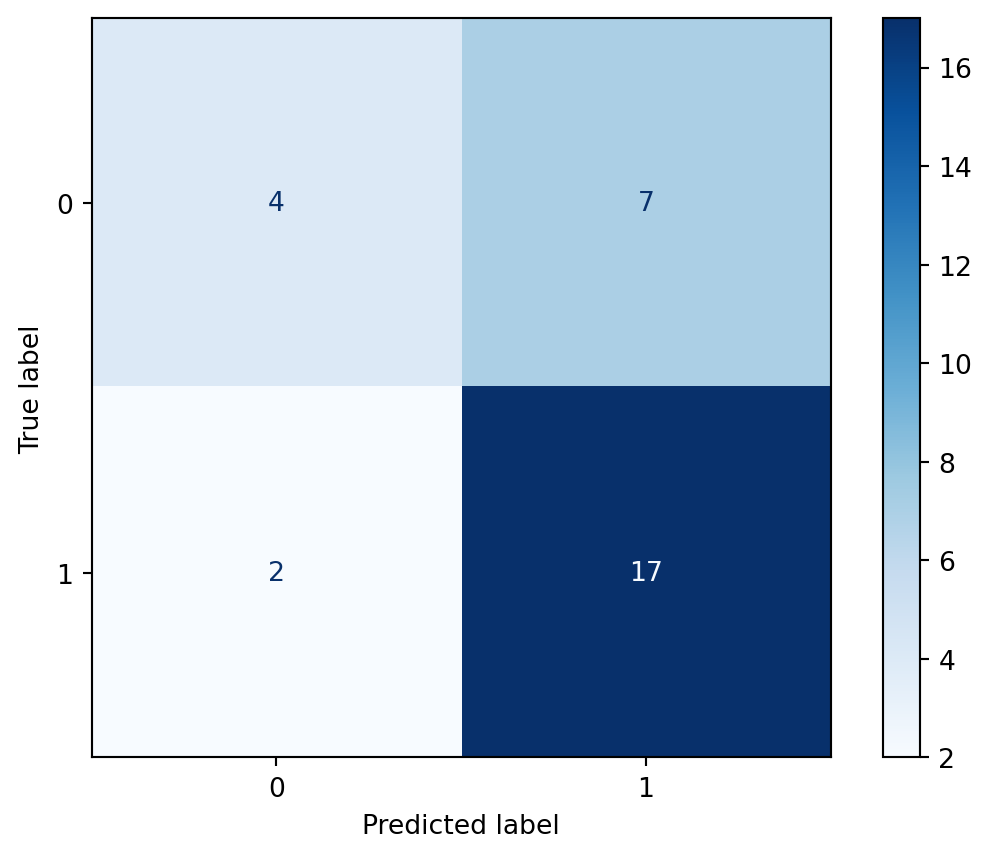

```python
# confusion matrix
print(confusion_matrix(y_test, y_pred))

# visualize confusion matrix
ConfusionMatrixDisplay.from_predictions(
                                      y_test,
                                      y_pred,
                                      cmap = plt.cm.Blues)
```

**Decision Tree**

```python
# cross-validation to estimate ROC AUC
scores = cross_val_score(dt_best_pipeline,
                         X=X_test,
                         y=y_test,
                         scoring="roc_auc",
                         cv=5)
scores.mean()
```

```
np.float64(0.48611111111111105)
```

```python
# classification report for accuracy, precision, recall, f1
y_pred = cross_val_predict(dt_best_pipeline, X_test, y_test, cv=5)
print(classification_report(y_test, y_pred))
```

```
              precision    recall  f1-score   support

           0       0.44      0.36      0.40        11
           1       0.67      0.74      0.70        19

    accuracy                           0.60        30
   macro avg       0.56      0.55      0.55        30
weighted avg       0.59      0.60      0.59        30
```

```
[[ 4  7]
 [ 5 14]]
```

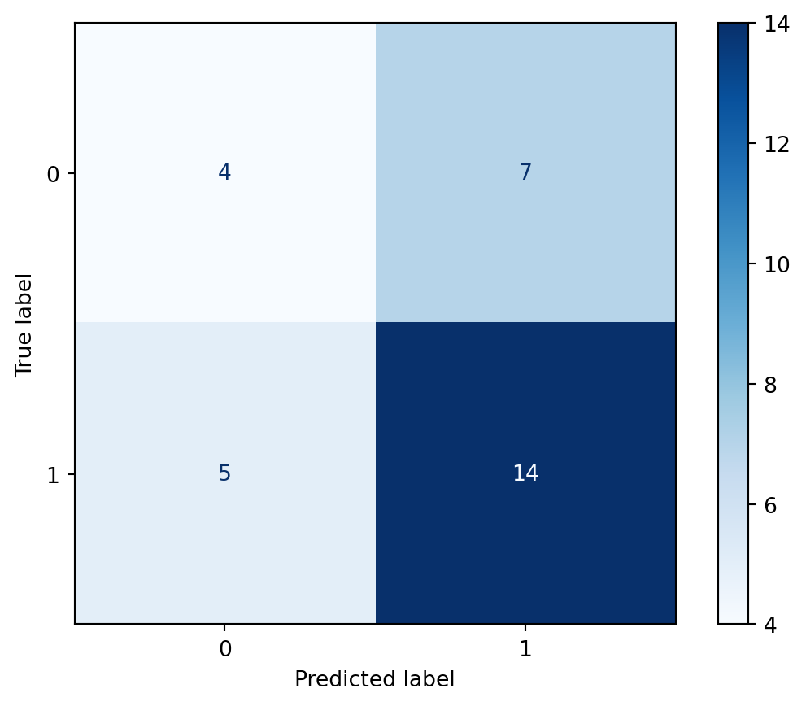

```python
# confusion matrix
print(confusion_matrix(y_test, y_pred))

# visualize confusion matrix
ConfusionMatrixDisplay.from_predictions(
                                      y_test,
                                      y_pred,
                                      cmap = plt.cm.Blues)
```

**KNN**

- train_ROC AUC: 0.8067377541998232
- test_ROC AUC: 0.7513888888888889
- train_precision: 0.80
- test_precision: 0.73
- train_recall: 0.67
- test_recall: 1.00

**Logistic Regression**

- train_ROC AUC: 0.8676222811671088
- test_ROC AUC: 0.65
- train_precision: 0.78
- test_precision: 0.71
- train_recall: 0.82
- test_recall: 0.89

In every case, the ROC AUC and precision values decreased from the train data to the test data, however the sensitivity / recall values stayed the same or increased. That suggests that the models all tend to have more false positives than false negatives when used with new data.

The KNN model has the highest ROC AUC with the test data, so it might be the most robust choice for predicting on unseen data. I’d say the measures of success did not turn out to be particularly close to the validation data.

# Part Five: Cohen’s Kappa

The below chart shows the Cohen’s Kappa values for each model in Part 1. This value represents the level of agreement between the model’s predictions and the actual outcomes, with 1 being perfect agreement and <0 being less than chance agreement.

```python
# create empty list for kappas
kappas = []

# calculate and save kappa values
kappas.append(cohen_kappa_score(y, y_pred_knn))
kappas.append(cohen_kappa_score(y, y_pred_lg))
kappas.append(cohen_kappa_score(y, y_pred_dt))

# create dataframe for comparing kappa values
kappa_compare = pd.DataFrame({
    "model": ["KNN", "Logistic", "Decision Tree"],
    "kappa_value": kappas
})

# display
kappa_compare.sort_values(by = "kappa_value", ascending = False)
```

|  | model | kappa_value |
| --- | --- | --- |
| 1 | Logistic | 0.556938 |
| 2 | Decision Tree | 0.516607 |
| 0 | KNN | 0.476399 |

This metric helps us quantify more than just accuracy within the classification, since it factors in the possibility of agreement occurring by chance. In other words, it helps show how similar the model classifies results (predicts) vs. what actually happened (y).

This metric as a measure of model success could be preferable when the one type of case in the classification happens much less frequently than the other. For example, if only 5% of the hospital’s patients are diagnosed as at risk of a heart attack, one could just say no one is at risk of a heart attack and be correct with 95% accuracy. But that would be more influenced by random chance than actual diagnostic skill. Similarly, using Cohen’s Kappa for model selection is measuring the accuracy of the predicted diagnosis while penalizing models that might be performing accurately by mere chance because the target class is rare.

If I use Cohen’s Kappa to judge the models, I would conclude that the logistic regression performs the best. This model also had the highest ROC AUC (on the training data, KNN was higher on the test data). This makes sense, because the ROC curve shows sensitivity and specificity measures across all confusion matrix cutoff values to show how accurately a model classifies both target and non-target class cases. While the ROC curve does not account for accuracy from random chance, since it considers sensitivity and specificity, it is robust enough to handle situations when the target class is rare.